# `BISP-1`

# Bayesian Inference of Starlight Polarization in 1D

## Usage Tutorial

With this notebook we learn how to use `BISP-1` to decompose stellar polarization data along distance.

Author: V.Pelgrims

### 1. Introduction

The code uses the object oriented programming. It allows us to handle sample of starlight polarization with distance, perform line-of-sight decompositions of the polarization signal according to the *layer model* , for one to five layers, visualize the data set and the results, and compare the different reconstructions.

The maximum-likelihood analysis of the data relies on the `dynesty` software (an efficient python implementation of a nested sampling method) to estimate the posterior distributions of the model parameters (six parameters per layer) and the evidence of the tested model. To compare different models (i.e. different number of layers placed along the sightlines) we rely on the Akaike Information Criterion. The latter makes it possible to estimate the probability of every tested models to actually be the model that minimizes the loss of information.

Each *layer* (a dust cloud of the magnetized ISM) is described by six parameters which are:

- plx: the parallax of the layer (1/distance)
- q: the mean q Stokes parameter of the layer
- u: the mean u Stokes parameter of the layer
- Cqq, Cuu, Cqu: the three independent elements of the covariance matrix through which the effect of turbulence (what we call the *intrinsic scatter*) on the observed q's and u's is characterized.

Below we make use of simulated samples of starlight polarization data with known distance and use them to illustrate the basic usage and available utilities of `BISP-1`.

### 2. Overview

The general idea behind the structure of the code is the following. We want an object

- that represents a "line of sight" through the Galaxy (i.e., that includes all the stars in a small angular opening),
- that we can manipulate for visualization and
- on which we can test different models (i.e., test the number of layers along the distance) and
- that could be queried to access all the information related to the results of the decomposition (i.e., access the posterior distributions, etc.).

This object, which we call `Bisp`, contain as attributes, and among other things, other important objects:

- `Stars`: object containing the star data given as input
- `Priors`: object specifying our prior knowledge on the model parameters and used to carry the Bayesian experiment on the star data
- `Decomp`: object containing the results from applying the maximum-likelihood analysis of the data assuming different models (different number of clouds along the sightlines).

To initialize a `Bisp` object, we need to pass as input a sample of stars and some prior knowledge (which may be uninformative) assuming that we could test any of the implemented models (one to five layer model). Then it is up to us to decide which model to try and which not to.

Now let's start manipulating the code to understand how the different parts are interconnected and explore its possibilities.

Let's start by importing the library (and other useful ones).

```python
# Imports
import BISP_1 as bisp
import numpy as np
import matplotlib.pyplot as plt
plt.rcParams['font.size'] = 14
```

### 3. `bisp.Stars` or how to handle your star data sample

In `BISP-1`, a `Stars` object is created from a given data set. The input data set can be a numpy array (which must comply with an assumed structure, see below) or a path/filename to a .csv or .ascii file. The latter must also follow some conventions in the naming of the column data.

1. if the input is an array, it must be of the shape (7,Nstars) where Nstars is the number of stars in the sample. The column must record the data: (q, u, plx, s_q, s_u, c_qu, s_plx) where:
   - q and u: are the Stokes parameters normalized to intensity, given in fractional units (i.e., a value of 1 = 100% polarized)
   - s_q and s_u are the uncertainties on q and u
   - c_qu is the covariance between q and u (from observational uncertainties)
   - plx is the parallax of the stars, given in mas (milli-arcsecond)
   - s_plx is the uncertainty on plx
2. if the input is a string, pointing to a catalog in .csv (or .ascii) format, the column labels should strictly follow this nomenclature:
   - 'plx': the parallax (same units as above)
   - 's_plx': the uncertainty on 'plx'
   - 'q_obs': the q Stokes parameter (same units as above)
   - 'u_obs': the u Stokes parameter
   - 's_q': the uncertainty on 'q_obs'
   - 's_u': the uncertainty on 'u_obs'
   - 'c_qu': (optional) the covariance between 'q_obs' and 'u_obs' (per star). If not given, c_qu = 0 for all stars.

An error message will show up if the labels do not comply.

```python
# create an object
filename = 'sample_1C.csv'
mystars = bisp.Stars(filename)
```

The `Stars` object hence created contains a few attributes and two handy-plotting functions can be applied to it.

- Attributes:
  - nStar: the number of stars
  - plx_max: the maximum value of star parallaxes
  - plx_min: the minimum value of star parallaxes
  - qu_max: the maximum value of the absolute values of both q and u Stokes parameters
  - stararray: a (7,nStar) numpy array containing the data set and following the (q,u,plx,s_q,s_u,c_qu,s_plx) structure.
- Functions:
  - showData_QUscatter(): create a scatter plot of the data in the (q,u) plane colouring the data points according to their distance modulus
  - showData_QUMU(): create a scatter plot of the data in the (q,u)-$\mu$ plane, where $\mu$ is the distance modulus

The plotting functions return python plots. Several options are available to control the outputs like minimum and maximum values in x,y, and distance.

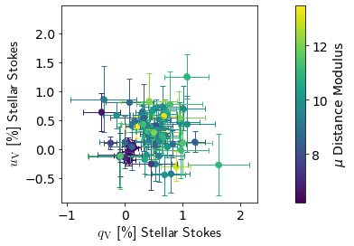

```python
# show a scatter plot of the data in the polarization plane
mystars.showData_QUscatter()
```

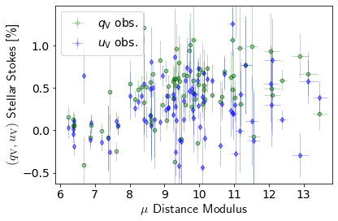

```python
# show a scatter plot of the data in the (q,u)-$\mu$ plane
mystars.showData_QUMU()
plt.legend();
plt.tight_layout();
```

### 4. `bisp.Priors` or how to handle your priors

In `BISP-1` a `Priors` object is created to initialize and set up the priors on the model parameters that should be used during the modeling experiment that we will run later.

There are two options for the type of priors to be used. One is 'Flat', i.e. uniform prior defined by minimum and maximum values, and the other is 'Gauss' for Gaussian priors defined by the mean and standard deviation. The type and values to be used for each model parameter is controled independently and also independently for each layer.

The default initialization of the priors uses the star data to define the range of parameter values. So, at least the `Stars` object needs to be passed.

The default setup is that

- the range of cloud parallax is defined between the minimum and maximum parallax of the stars
- the mean q and u of the cloud is defined in the range $\pm$ the maximum of the absolute values of the q's and u's of the star polarization
- Cqq and Cuu are defined in the range [0,10^{-4}]; the maximum value corresponding to a value of the standard deviation induced by the intrinsic scatter = 0.01 in polarization fraction (this is a lot)
- Cqu in [-10^{-4},10^{-4}] with the extra condition that $C_{qu}^2 < C_{qq} C_{uu}$

By default the initialization of a `Priors` object generates list of types and values for the five models that we consider and all priors are considered to be uniform. To each model corresponds a `ModelPriors` object which is made of `LayerPriors` objects, as many as the number of layers has the model.

Let us create one `Priors` object and inspect it:

```python
# create the object with default initialization (no additional argument)
mypriors = bisp.Priors(mystars)

# print the list of attribute of the created object
print(mypriors.__dict__.keys());
```

```
dict_keys(['OneLayer', 'TwoLayers', 'ThreeLayers', 'FourLayers', 'FiveLayers'])
```

```python
# print the list of attribute
#   in the 'OneLayer'
print(mypriors.OneLayer.__dict__.keys())
#   in the 'TwoLayers'
print(mypriors.TwoLayers.__dict__.keys())
```

```
dict_keys(['layer_1', 'nlayers'])
dict_keys(['layer_1', 'layer_2', 'nlayers'])
```

Each `LayerPriors` has 6 attributes to specify the type of prior to be used and 12 attributes to specify the range (minimum and maximum) or mean and standard deviation to fully determine the functional form of the prior for each parameter.

```python
print(mypriors.TwoLayers.layer_1.__dict__.keys())
#
# look at the type and values for the plx corresponding to the first layer in the TwoLayers model:
print(mypriors.TwoLayers.layer_1.plx_type)
print(mypriors.TwoLayers.layer_1.plx_val1)
print(mypriors.TwoLayers.layer_1.plx_val2)
```

```
dict_keys(['plx_type', 'plx_val2', 'plx_val1', 'q_type', 'q_val1', 'q_val2', 'u_type', 'u_val1', 'u_val2', 'Cqq_type', 'Cqq_val1', 'Cqq_val2', 'Cuu_type', 'Cuu_val1', 'Cuu_val2', 'Cqu_type', 'Cqu_val1', 'Cqu_val2'])
Flat
0.3837596826170077
5.694534885339699
```

There are 2 functions that are used to return list of list of list of types and values of the parameters in each layer of a model. These are `getTypeList()` and `getValueList()` to be called on a `ModelPrior` object. Example:

```python
print(mypriors.OneLayer.getTypeList())
```

```
[['Flat', 'Flat', 'Flat', 'Flat', 'Flat', 'Flat']]
```

```python
print("length of types' list in OneLayer = ",len(mypriors.OneLayer.getTypeList()))
print("length of values' list in OneLayer = ",len(mypriors.OneLayer.getValueList()))
```

```
length of types' list in OneLayer =  1
length of values' list in OneLayer =  1
```

```python
print('length of list of types in OneLayer = ',len(mypriors.OneLayer.getTypeList()[0]))
print('length of list of values in OneLayer = ',len(mypriors.OneLayer.getValueList()[0]))
```

```
length of list of types in OneLayer =  6
length of list of values in OneLayer =  12
```

this totally makes sense since for the 'OneLayer' model, there is only one layer to model, using 6 parameters.

Now, for another model we get:

```python
print("length of types' list in ThreeLayers = ",len(mypriors.ThreeLayers.getTypeList()))
print("length of values' list in ThreeLayers = ",len(mypriors.ThreeLayers.getValueList()))

print('length of list of types in ThreeLayers = ',len(mypriors.ThreeLayers.getTypeList()[0]))
print('length of list of types in ThreeLayers = ',len(mypriors.ThreeLayers.getValueList()[0]))
```

```
length of types' list in ThreeLayers =  3
length of values' list in ThreeLayers =  3
length of list of types in ThreeLayers =  6
length of list of types in ThreeLayers =  12
```

Therefore, if we have good reasons to think that the parallax of a nearby cloud in a 3-layer model has a mean of 400 pc with standard deviation of 50 pc (rougly speaking, corresponding to a cloud mean parallax and standard deviation of 2.5mas and 0.3mas), we could proceed as follow:

```python
# 1. picking the existing list of list, for the sake of brevity
my3L_type = np.copy(mypriors.ThreeLayers.getTypeList())
my3L_vals = np.copy(mypriors.ThreeLayers.getValueList())

# change the type and values for the first layer (first indice), for the parallax (second indice).
my3L_type[0][0] = 'Gauss'
my3L_vals[0][0] = 2.5
my3L_vals[0][6] = 0.3

print(my3L_type)
```

```
[['Gaus' 'Flat' 'Flat' 'Flat' 'Flat' 'Flat']
 ['Flat' 'Flat' 'Flat' 'Flat' 'Flat' 'Flat']
 ['Flat' 'Flat' 'Flat' 'Flat' 'Flat' 'Flat']]
```

```python
print(mypriors.ThreeLayers.getTypeList())
print(mypriors.ThreeLayers.getTypeList()[0][0])
my3L_type = mypriors.ThreeLayers.getTypeList()
print(my3L_type[0][0])
my3L_type[0][0] = 'Gauss'
print(my3L_type[0][0])
```

```
[['Flat', 'Flat', 'Flat', 'Flat', 'Flat', 'Flat'], ['Flat', 'Flat', 'Flat', 'Flat', 'Flat', 'Flat'], ['Flat', 'Flat', 'Flat', 'Flat', 'Flat', 'Flat']]
Flat
Flat
Gauss
```

Now we can pass this setup to the initialization of a `Priors` object as:

```python
mypriors2 = bisp.Priors(mystars,inputTypes=[my3L_type],inputValues=[my3L_vals])
```

**Notice** the extra squared bracket. This is beacuse we can pass a list of list of setup lists if we want to consider several models later on.

Functions:\ There are 2 functions to `Priors` object:

- updatePriors(): is used internaly to update the priors accroding to the input values. This is the function implicitely used in the previous line at the initialization of the priors. The function takes as input list of list (of list) of input and values. This function is used during the initialization of the `Priors` object.
- printPriors(): provided to ease the live of the users; it prints on the terminal summary tables with the types of priors for each parameters and each layers and with values used to specify the functional forms of each prior functions. The function takes as input the name of the model for which the tables of types and values are of interest.

We illustrate the use of printPriors():

```python
mypriors.printPriors('ThreeLayers')
```

```
 Prior Types:
 ------------

 Clouds plx   q    u   Cqq  Cuu  Cqu
------- ---- ---- ---- ---- ---- ----
Cloud 0 Flat Flat Flat Flat Flat Flat
Cloud 1 Flat Flat Flat Flat Flat Flat
Cloud 2 Flat Flat Flat Flat Flat Flat


 Prior Values:
 -------------

 Clouds plx_v1   q_v1    u_v1  Cqq_v1 ...  q_v2   u_v2  Cqq_v2 Cuu_v2 Cqu_v2
------- ------ ------- ------- ------ ... ------ ------ ------ ------ ------
Cloud 0 5.6945 -0.0162 -0.0162 0.0000 ... 0.0162 0.0162 0.0001 0.0001 0.0001
Cloud 1 5.6945 -0.0162 -0.0162 0.0000 ... 0.0162 0.0162 0.0001 0.0001 0.0001
Cloud 2 5.6945 -0.0162 -0.0162 0.0000 ... 0.0162 0.0162 0.0001 0.0001 0.0001

For 'Flat' priors 'v1' and 'v2' refer to minimum and maximum
 except for 'plx' where there are inverted as compared to plx_val1 and plx_val2.
For 'Gauss' priors 'v1' and 'v2' refer to mean and stddev.
```

```python
mypriors2.printPriors('ThreeLayers')
```

[output not shown]

Types and values in `Priors` can also be modified in a somewhat more transparent way by changing explicitly the type and values of a given parameters as examplified below. We can modify 'mypriors2' so that the prior on the parallax of the first cloud in the 3-layer model is uniform between 2 mas and 3 mas as:

```python
mypriors2.ThreeLayers.layer_1.plx_type = 'Flat'
mypriors2.ThreeLayers.layer_1.plx_val1 = 2.
mypriors2.ThreeLayers.layer_1.plx_val2 = 3.
# and print the table to see the effect by comparison with the above
mypriors2.printPriors('ThreeLayers')
```

```
 Prior Types:
 ------------

 Clouds plx   q    u   Cqq  Cuu  Cqu
------- ---- ---- ---- ---- ---- ----
Cloud 0 Flat Flat Flat Flat Flat Flat
Cloud 1 Flat Flat Flat Flat Flat Flat
Cloud 2 Flat Flat Flat Flat Flat Flat


 Prior Values:
 -------------

 Clouds plx_v1   q_v1    u_v1  Cqq_v1 ...  q_v2   u_v2  Cqq_v2 Cuu_v2 Cqu_v2
------- ------ ------- ------- ------ ... ------ ------ ------ ------ ------
Cloud 0 3.0000 -0.0162 -0.0162 0.0000 ... 0.0162 0.0162 0.0001 0.0001 0.0001
Cloud 1 5.6945 -0.0162 -0.0162 0.0000 ... 0.0162 0.0162 0.0001 0.0001 0.0001
Cloud 2 5.6945 -0.0162 -0.0162 0.0000 ... 0.0162 0.0162 0.0001 0.0001 0.0001

For 'Flat' priors 'v1' and 'v2' refer to minimum and maximum
 except for 'plx' where there are inverted as compared to plx_val1 and plx_val2.
For 'Gauss' priors 'v1' and 'v2' refer to mean and stddev.
```

Okay, now we have a sample of stars, we have decided on some priors to be used. Let's start the modeling!

### 5. `bisp.Bisp` or how to run `BISP-1`

Here is where all the modeling computation happen.

First we create an object `Bisp` which will have as attributes

- stars: a `Stars` object
- priors: a `Priors` object
- dynesty_settings: a dictionary with `dynesty` settings to control the sampling experiment
- testedModel: a list with the names of models already tested (if some)
- other `Decomp` objects (if some) wrapping `dynesty` results (the samplers) from the application of the decomposition method under specified models; e.g.
  - OneLayer
  - TwoLayers
  - etc.

To create or initialize the `Bisp` object, we need to pass it an object `Stars` and an object `Priors`.

```python
mylos = bisp.Bisp(mystars,mypriors)
```

Then we can decide on running a given model to the data; i.e. to analyze the star data through our maximum-likelihood method, based on a model (number of layers) and priors. This will have for an effect to add a `Decomp` object with the name of the tried model to the `Bisp` object.

The different possible models can be tested by applying the following functions to the `Bisp` object:

> run_OneLayer() \ run_TwoLayers() \ run_ThreeLayers() \ run_FourLayers() \ run_FiveLayers() .

The corresponding following `Decomp` object will be added as attribute to the `Bisp` object:

> OneLayer \ TwoLayers \ ... \ FiveLayers .

These objects can then be accessed later on for post processing etc. We will see that in the next section.

The `Bisp` object has also other functions to return the summary of already performed decompositions and compare the results:

- GetSummaryStat(): returns an astropy table with model name and statistic on the tested model: evidence, uncertainty on evidence, maximum log-likelihood obtained, AIC and the probability among all tested model that each model is the one that minimize the loss of information
- printSummaryStat(): prints on the shell the output of GetSummaryStat() with given numerical precision (default is '%.4f' and can be changed using the function optional argument 'numformat')
- writeSummaryStat(outputfilename): write the output of GetSummaryStat() as .csv file with the given name. Default numerical precision is set to '%.4f' but can be changed using the optional argument 'numformat'.
- default_dynestycontrol(): set to default the list of controls recorded in the `dynesty_settings` attribute that is used to initialize and control the behavior of `dynesty` during the sampling experiment.
- update_dynestycontrol(settinglist): change the `dynesty_settings` attribute according to input in settinglist.

Now, let's look at the object we created above, run a first decomposition and look at it again.

```python
print('Already tested model: ',mylos.testedModel)
print('there is none, obviously.')
```

```
Already tested model:  []
there is none, obviously.
```

```python
# This will take some time...
# run the OneLayer model
mylos.run_OneLayer()
print('Already tested model: ',mylos.testedModel)
#
# run the TwoLayers model
mylos.run_TwoLayers()
print('Already tested model: ',mylos.testedModel)
```

```
Already tested model:  ['OneLayer']
Already tested model:  ['OneLayer', 'TwoLayers']
```

By default we ask `dynesty` not to display progresses. We can change this by changing in `mylos.dynesty_settings` the ''silent'' keyword to 'False' instead of 'True' as follows:

```python
mylos.dynesty_settings['silent'] = False
# then re-do the decomposition of the OneLayer model to see the effect:
mylos.run_OneLayer()
```

```
10001it [00:14, 669.06it/s, +500 | bound: 45 | nc: 1 | ncall: 52128 | eff(%): 20.145 | loglstar:   -inf < 784.568 <    inf | logz: 766.414 +/-  0.257 | dlogz:  0.000 >  0.100]
```

In the above, the sampling experiment has restarted from the beginning,erasing completely the information from the first run of the decompositions.

We can decide to restart from where the previous run has been left using the 'fromFresh' optional argument in function. This can be useful for example if we find after inspection of the first results that some more iterations are needed.

Let show an example. From the beginning.

```python
mylos = bisp.Bisp(mystars,mypriors)
# run with the default dynesty controls
# but show the progress for now:
mylos.dynesty_settings['silent'] = False
mylos.run_OneLayer()
print('OneLayer done.')
mylos.run_TwoLayers()
print('TwoLayers done.')
print('Already tested model: ',mylos.testedModel)
#
# ask for more precision on logz
mylos.dynesty_settings['dlogz'] = 0.05 # default is at 0.1
# allow for more iteration if need be
mylos.dynesty_settings['maxiter'] = 20000 # default is at 10000
#
# pursue the sampling, starting from where we left them
mylos.run_OneLayer(fromFresh=False)
print('new OneLayer done.')
mylos.run_TwoLayers(fromFresh=False)
print('new TwoLayers done.')
print('\n Already tested model: ',mylos.testedModel)
```

```
10001it [00:14, 693.35it/s, +500 | bound: 41 | nc: 1 | ncall: 49077 | eff(%): 21.397 | loglstar:   -inf < 784.530 <    inf | logz: 766.592 +/-  0.254 | dlogz:  0.000 >  0.100]
279it [00:00, 2779.41it/s, bound: 0 | nc: 2 | ncall: 883 | eff(%): 31.597 | loglstar:   -inf < 423.373 <    inf | logz: 417.652 +/-  0.143 | dlogz: 279.358 >  0.100]
```

```
OneLayer done.
```

```
10001it [00:58, 171.12it/s, +500 | bound: 148 | nc: 1 | ncall: 223281 | eff(%):  4.703 | loglstar:   -inf < 782.461 <    inf | logz: 760.261 +/-  0.476 | dlogz:  0.018 >  0.100]
10139it [00:00, 101119.36it/s, bound: 42 | nc: 6 | ncall: 49588 | eff(%): 20.446 | loglstar:   -inf < 783.892 <    inf | logz: 766.527 +/-  0.247 | dlogz:  0.101 >  0.050]
```

```
TwoLayers done.
Already tested model:  ['OneLayer', 'TwoLayers']
```

```
10490it [00:00, 31417.42it/s, +500 | bound: 43 | nc: 1 | ncall: 50689 | eff(%): 21.681 | loglstar:   -inf < 784.545 <    inf | logz: 766.593 +/-  0.250 | dlogz:  0.000 >  0.050]
10020it [00:00, 97076.69it/s, bound: 148 | nc: 25 | ncall: 223756 | eff(%):  4.478 | loglstar:   -inf < 778.503 <    inf | logz: 758.751 +/-  0.269 | dlogz:  3.718 >  0.050]
```

```
new OneLayer done.
```

```
13374it [00:20, 656.56it/s, +500 | bound: 199 | nc: 1 | ncall: 307652 | eff(%):  4.510 | loglstar:   -inf < 784.125 <    inf | logz: 760.397 +/-  0.284 | dlogz:  0.000 >  0.050]
```

```
new TwoLayers done.

 Already tested model:  ['OneLayer', 'TwoLayers']
```

Fantastic. Now, look at the summary table to compare the tested models:

```python
mylos.printSummaryStat()
```

```
  Model      Z      errZ   max-LL     AIC     Pbest
--------- -------- ------ -------- ---------- ------
 OneLayer 766.5930 0.2502 784.5450 -1557.0900 1.0000
TwoLayers 760.3973 0.2840 784.1245 -1544.2491 0.0016
```

According to the 'Pbest' values (the probabilities that, among the tested models, a model minimizes the loss of information), the 1-layer model performs significantly better than the 2-layer model.

If we now look at the attribute of our `Bisp` object we also notice that there are attributes corresponding to the performed decompositions. These are the 'OneLayer' and the 'TwoLayers' attributes. These are `Decomp` objects that wrapped the `dynesty` samplers and allow us to perform some extra manipulations that are necessary in our business.

```python
print(mylos.__dict__.keys())
```

```
dict_keys(['stars', 'priors', 'testedModel', 'dynesty_settings', 'OneLayer', 'TwoLayers'])
```

### 5. `bisp.Decomp` or how to dive into the decomposition results

`Decomp` objects wrap the `dynesty` sampler and make it easy to manipulate the results through the use of handy functions. `Decomp` objects have one attribute 'sampler': the `dynesty` sampler. Several functions are available:

- PosteriorSamples(): returns an array (Nsample,Nparam) of Nsample sets of parameters extracted from the sampling experiment (after re-weigthing).
- SummaryStat(): read the evidence, error on evidence and maximum log-likelihood from the sample
- Values_at_MaxLikelihood(): returns an array of parameter values corresponding to the maximum log-likelihood values reached
- CloudProperties(): returns descriptive statistics on the model parameters (mean and standard deviation, thus assuming the posteriors are Gaussian).
- printCloudProperties(): prints on the shell the outputs of CloudProperties() with a numerical format set to '%.4f' which can be changed using the function optional argument numformat
- showPosteriors(): outputs a corner plot of the model parameters. ! There are 6 parameters per layer. The quality of the corner plots is therefore not guarenteed
- showPosteriors_meanPol() same as showPosteriors() but outputs only the parallax and mean Stokes q and u for each layer. That is, the parameters describing the intrinsic scatter are dropped
- overPlot_QUMUClouds(): over plot on an existing figure the (q,u)-mu obtained for the model

We can illustrate the usage of these function on the decomposition we performed above:

```python
print('Cloud properties from OneLayer model:')
mylos.OneLayer.printCloudProperties();
```

```
Cloud properties from OneLayer model:
 Clouds  plxC  err_plxC   qC   err_qC   uC   err_uC  dMaha0
------- ------ -------- ------ ------ ------ ------ -------
Cloud 0 2.7096   0.1344 0.0051 0.0003 0.0032 0.0003 21.0594
```

```python
print('Cloud properties from TwoLayers model:')
mylos.TwoLayers.printCloudProperties();
```

```
Cloud properties from TwoLayers model:
 Clouds  plxC  err_plxC   qC   err_qC    uC   err_uC  dMaha0
------- ------ -------- ------ ------ ------- ------ -------
Cloud 0 2.7069   0.1347 0.0051 0.0003  0.0033 0.0003 20.0707
Cloud 1 0.2448   0.0447 0.0003 0.0071 -0.0005 0.0073  0.0789
```

Create a corner plot to show the 1D and 2D marginalized posterior distributions of our model parameters.

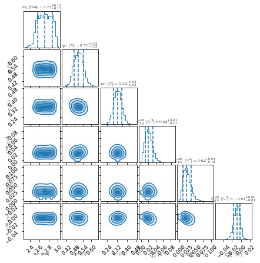

```python
mylos.OneLayer.showPosteriors()
```

Same as above but for the TwoLayers model, dropping the parameters on the intrinsic scatter.

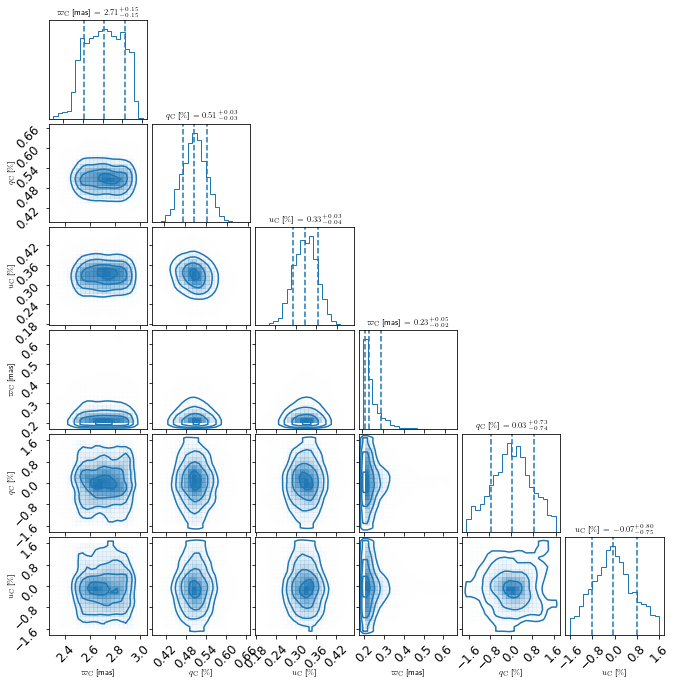

```python
mylos.TwoLayers.showPosteriors_meanPol()
```

We see that the parameters of the second clouds are not very well constrained and the 2nd cloud parallax is squeezed the furthest it could. This is an indication that there might not be a second layer for that sightline, thus explaining why the 1-layer model outperforms the 2-layer model, as we saw earlier.

Finally, we can create nice plot showing the results. Visualization is always instructive.

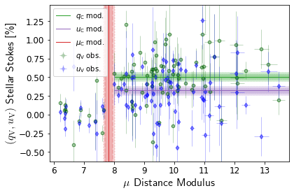

```python
mylos.stars.showData_QUMU();
mylos.OneLayer.overPlot_QUMUClouds();
plt.legend(fontsize=10)
plt.tight_layout()
```

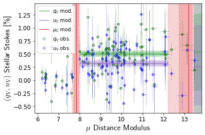

```python
mylos.stars.showData_QUMU();
mylos.TwoLayers.overPlot_QUMUClouds();
plt.legend(fontsize=10)
plt.tight_layout()
```

### 6. Final note

All the functions are documents in the code and the info can be accessed through the usual help() function.

To conclude, we run our pipeline from start for another sample of stars, test 4 models and compare them and look at the best result.

This will take some times!

```python
mystars = bisp.Stars('sample_2C.csv')
mypriors = bisp.Priors(mystars)
mylos = bisp.Bisp(mystars,mypriors,dlogz=0.05,maxiter=200000)
#
mylos.run_OneLayer()
print('OneLayer done.')
mylos.run_TwoLayers()
print('TwoLayers done.')
mylos.run_ThreeLayers()
print('ThreeLayers done.')
mylos.run_FourLayers()
print('FourLayers done.')
```

```
OneLayer done.
TwoLayers done.
```

```
ThreeLayers done.
FourLayers done.
```

```python
mylos.printSummaryStat()
```

```
   Model       Z      errZ   max-LL     AIC     Pbest
----------- -------- ------ -------- ---------- ------
   OneLayer 688.1581 0.2375 704.5650 -1397.1300 0.0000
  TwoLayers 708.2505 0.3228 739.0797 -1454.1594 1.0000
ThreeLayers 705.2116 0.3326 738.3405 -1440.6809 0.0012
 FourLayers 699.1784 0.3483 738.2121 -1428.4243 0.0000
```

The 2-layer model appears to be, by far, the best model to fit the data. Let's look at the results we have for it.

```python
#print cloud properties
mylos.TwoLayers.printCloudProperties()
```

```
 Clouds  plxC  err_plxC   qC   err_qC    uC   err_uC  dMaha0
------- ------ -------- ------ ------ ------- ------ -------
Cloud 0 2.7203   0.1396 0.0156 0.0006 -0.0114 0.0006 54.5692
Cloud 1 0.7840   0.0442 0.0009 0.0018  0.0094 0.0016  6.8883
```

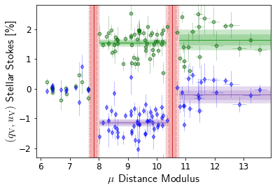

```python
# look at the summary plot in (q,u)-mu plane
mylos.stars.showData_QUMU()
mylos.TwoLayers.overPlot_QUMUClouds()
```

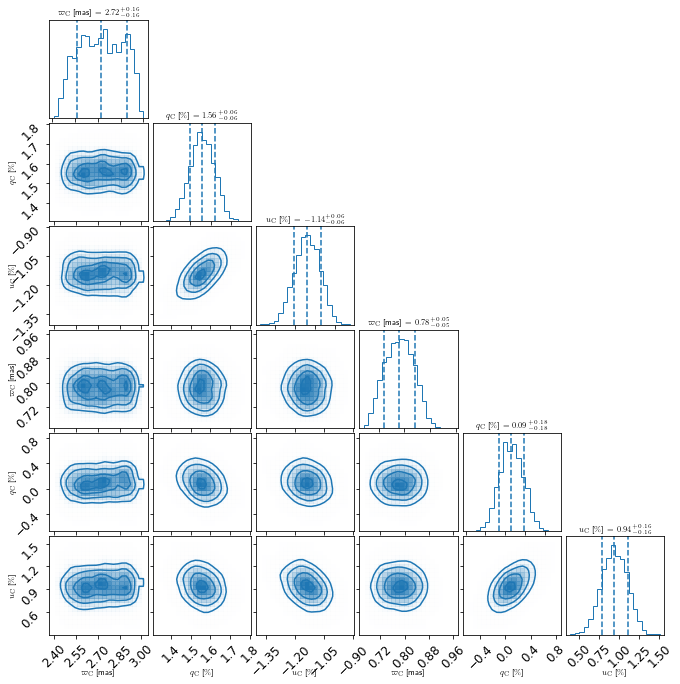

```python
# look at the posterior distribution (dropping the parameters of the intrinsic scatter)
mylos.TwoLayers.showPosteriors_meanPol()
```

Any question / feedback / comment are welcome. Contact me!

Vincent